# warmup01-jacqueline-wood

# Warmup 01

## Star Wars: Hype Fazon

> “Ace One to squadron, Light ’em up!” ―Hype Fazon

[figure not shown]

| Physical Description |  |
| --- | --- |
| Species | Rodian |
| Gender | Male |
| Eye color | Blue |
| Skin color | Green |

## Cooking Recipe: Easiest French Fries

### Ingredients:

*2 1/2 pounds (1 1/8 kg) Yukon Gold potatoes (about 6 medium)* 6 cups (1.4 liters) peanut oil *Fine sea or table salt

### Special Kitchen Tools:

*large baking sheet* 4 to 5-quart heavy, deep frying pan *tongs* large slotted spoon

### Recipe:

*cut potatoes into 1/4-inch batons* place in 4 to 5-quart heavy, deep frying pan and add oil *turn burner to high and bring oil to boil (takes about 5 minutes)* cook potatoes for another 15 minutes *after 20 minutes, can use tongs to gently scrape loose any potatoes stuck to the pan* continue to cook for 5-10 minutes longer or until crisp and golden *use large slotted spoon to scoop potatoes from pan and spread them on tray* toss immediately with salt

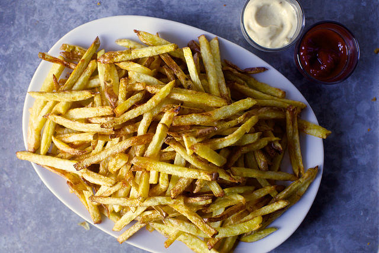

Fries can be eaten year round, but are a popular summer food.

There are variations of the recipe that involve peeking, soaking, twice-frying, temperature monitoring etc. but those recipes are not as easy. Most recipes involve similar ingredients.

## Euclidean Distance

The Euclidean distance between points p and q is the length of the line segment connecting them $\bar{pq}$.

In Cartesian coordinates, if p = (p1, p2,…, pn) and q = (q1, q2,…, qn) are two points in Euclidean n-space, then the distance (d) from p to q, or from q to p is given by the Pythagorean formula:

d(p,q) = d(q,p) = $\sqrt{(q_{1} - p_{1})^2 + (q_{2} - p_{2})^2 + ... + (q_{n} - p_{n})^2}$ = $\sqrt{\sum_{i=1}^{n} (q_{i} - p_{i})^2}$